# Machine Learning: Mathematical Theory and Applications

#### 💪 Problem 1.3

Polynomials are global functions and their fit may be sensitive to outliers. Local fitting methods can sometimes be more robust. One such method is the `loess` method, which is a nonparametric method that fits locally weighted regressions to subsets of points and subsequently combines them to obtain a global fit. Use the `loess` function in R with the standard settings to fit a locally weighted regression to the training data. Is this method better than that in Problem 1.1? Plot the training data, test data and both fitted curves in the same plot.

**Tip**

The `predict()` function can be used on the object returned by `loess()`.

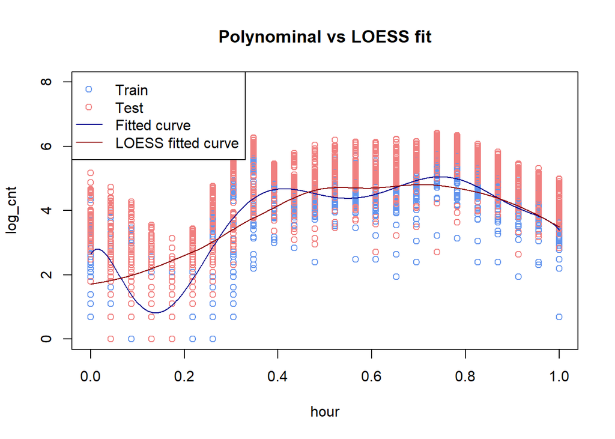

```r
#=== 1.Prepare data
y_train <- bike_data_train$log_cnt
y_test <- bike_data_test$log_cnt

#=== 2.LOESS model

  #--- Fit a LOESS model to the training data
  loess_fit <- loess(log_cnt ~ hour,data = bike_data_train)

  #--- Predict in-sample and out-of-sample y hat
  yhat_train_loess <- predict (loess_fit, newdata = bike_data_train)
  yhat_test_loess <- predict (loess_fit, newdata = bike_data_test)

  #--- Compute RMSE
  RMSE_train_loess <- sqrt (mean((y_train - yhat_train_loess)^2))
  RMSE_test_loess <- sqrt (mean ((y_test - yhat_test_loess)^2))

#=== 3.Plot comparison
plot (log_cnt ~ hour, data=bike_data_train, col = "cornflowerblue", pch = 1, ylim = c (0,8), main = "Polynominal vs LOESS fit")
lines(bike_data_test$hour, bike_data_test$log_cnt, type = "p", col = "lightcoral")

hours_grid <- seq(0,1, length.out = 1000)
yhat_grid_loess <- predict (loess_fit, newdata = data.frame(hour = hours_grid))
lines (hours_grid, y_hat_grid, lty = 1, col = "darkblue")
lines (hours_grid, yhat_grid_loess,lty = 1, col ="darkred")

legend (x = "topleft", pch = c(1,1,NA,NA), lty = c(NA, NA, 1, 1) , col = c("cornflowerblue","lightcoral", "darkblue", "darkred"), legend = c("Train", "Test", "Fitted curve", "LOESS fitted curve"))
```

```r
#=== 5. Comparison with Model polynomial of order 8 and conclusion
RMSE_comparison <- data.frame (Model = c("Polynominal (deg 8)", "LOESS"), RMSE_Train = c(RMSE_train_poly, RMSE_train_loess), RMSE_Test = c(RMSE_test_poly, RMSE_test_loess))

print (RMSE_comparison)
```

```
                Model RMSE_Train RMSE_Test
1 Polynominal (deg 8)  0.7232024  1.021449
2               LOESS  0.8989078  1.120946
```

```r
#Conclusion:
```

## 2. Regularised spline regression for bike rental data (3 marks)

Using the same training and test datasets as above, we will fit spline regressions with L1 and L2 regularisations (also known as penalties).

We create a natural cubic spline basis function for the variable hour with 25 equally spaced knots between 0.05 and 0.95. We first fit a regression using least squares without regularisation. The following code does this and plots the spline fit together with the training and test data. Note that we are not adding an intercept to the design matrix, since this is taken care of by the argument `intercept=TRUE`.

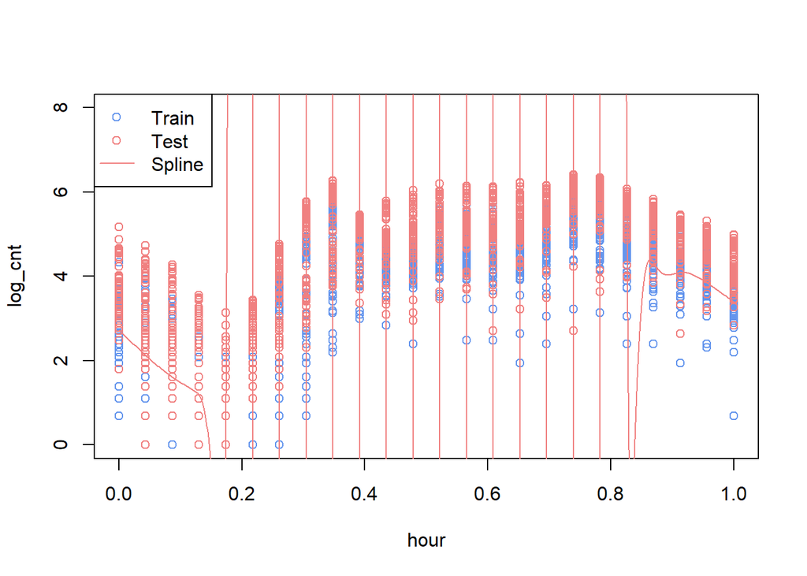

```r
suppressMessages(library(splines))
knots <- seq(0.05, 0.95, length.out = 25)
X_train <- ns(bike_data_train$hour, knots = knots, intercept = TRUE)
X_test <- ns(bike_data_test$hour, knots = knots, intercept = TRUE)
beta_hat <- solve(t(X_train)%*%X_train)%*%t(X_train)%*%y_train

# Plot training data, test data, and spline fit on a fine grid.
plot(log_cnt ~ hour, data = bike_data_train, col = "cornflowerblue", ylim = c(0, 8))
lines(bike_data_test$hour, bike_data_test$log_cnt, type = "p", col = "lightcoral")
hours_grid <- seq(0, 1, length.out = 1000)
X_grid <- ns(hours_grid, knots = knots, intercept = TRUE) # cbind(1, ns(hours_grid, knots = knots))
y_hat_spline_grid <- X_grid%*%beta_hat
lines(hours_grid, y_hat_spline_grid, lty = 1, col = "lightcoral")
legend(x = "topleft", pch = c(1, 1, NA), lty = c(NA, NA, 1), col = c("cornflowerblue", "lightcoral",  "lightcoral"), legend=c("Train", "Test", "Spline"))
```

We have deliberately chosen too many knots and no regularisation so that the fit has a large variance, which is clearly evident from the figure above. Your task in the next problem is to fit a regularised spline regression.

#### 💪 Problem 2.1

Fit a spline regression to the training data with an L2 regularisation using a suitable value of $\lambda$, without using R functions such as `glmnet()`. Plot the fit together with the training and test data.

**Tip**

The least squares estimator when using an L2 penalty is known as the Ridge regression estimator. Moreover, to determine a suitable value of $\lambda$, one approach is to fit several models (using different $\lambda$ values, e.g. `lambda_grid <- seq(0, 1, length.out=100)`) and choose the value of $\lambda$ that minimises the root mean squared error of the test data.

```r
suppressMessages(library(splines))
knots <- seq (0.05, 0.95, length.out = 25)
#=== Design new matrix of feature using natural cubic spline
x_train <- ns (bike_data_train$hour, knots = knots, intercept = TRUE)
x_test <- ns (bike_data_test$hour, knots = knots, intercept = TRUE)

#=== 1. Create lambda grid and empty vectors to store RMSE results
lambda_grid <- seq (0, 1, length.out = 100)
RMSE_spline_test <- numeric (length(lambda_grid))

#=== 2. Loop over 100 Lambda values to determine suitable λ
for (i in 1:length(lambda_grid)) {
  lambda <- lambda_grid[i]
  I <- diag(ncol(x_train))

  #--- Ridge regression for each λ
  beta_spline <- solve (t(x_train)%*%x_train + lambda*I)%*%t(x_train)%*%y_train
  yhat_test_spline <- x_test%*%beta_spline

  #--- Compute RMSE
  RMSE_spline_test [i] <- sqrt (mean((y_test - yhat_test_spline)^2)) }

RMSE_spline_table <- data.frame(Lambda = lambda_grid, RMSE_spline_test)
print (RMSE_spline_table)
```

```
        Lambda RMSE_spline_test
1   0.00000000         1.038200
2   0.01010101         1.006595
3   0.02020202         1.007135
4   0.03030303         1.007675
5   0.04040404         1.008216
6   0.05050505         1.008756
7   0.06060606         1.009297
8   0.07070707         1.009838
9   0.08080808         1.010379
10  0.09090909         1.010920
11  0.10101010         1.011462
12  0.11111111         1.012003
13  0.12121212         1.012545
14  0.13131313         1.013086
```

[output cut: 86 more lines]

```r
#=== 3. Report the Lambda that minimizes the test RMSE
best_lambda <- lambda_grid[which.min(RMSE_spline_test)]
cat("Best λ (min test RMSE)", best_lambda)
```

```
Best λ (min test RMSE) 0.01010101
```

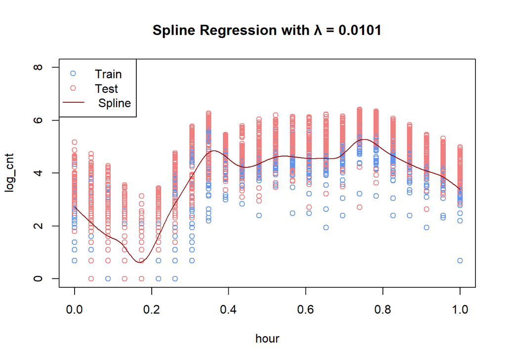

```r
#=== 4. Refit the model using the best lambda
beta_best <- solve (t(x_train)%*%x_train + best_lambda*I)%*%t(x_train)%*%y_train

#=== 5. Plot on a fine grid
plot (log_cnt ~ hour, data = bike_data_train, col = "cornflowerblue", pch = 1, ylim = c(0,8), main = paste("Spline Regression with λ =", round(best_lambda,4)))
lines (bike_data_test$hour, bike_data_test$log_cnt, type = "p", col ="lightcoral")

hours_grid <- seq(0,1, length.out = 1000)
xspline_grid <- ns (hours_grid, knots = knots, intercept = TRUE) #cbind (1, ns(hours_grid, knots = knots))
yspline_grid <- xspline_grid%*%beta_best
lines (hours_grid, yspline_grid, lty = 1, col ="darkred")
#Ridge Spline fitted curve

legend ( x = "topleft", pch = c(1,1, NA), lty = c (NA, NA, 1), col= c("cornflowerblue","lightcoral","darkred"),legend = c("Train", "Test", " Spline"))
```

#### 💪 Problem 2.2

Use the package `glmnet` to fit a spline regression with an L2 regularisation using the same basis functions as the previous problem. Find the optimal $\lambda$ by applying the one-standard deviation rule when cross-validating the training data using 10 folds. Compute the RMSE (using the optimal $\lambda$) for the training and test data. Plot the fit together with the training and test data.

**Tip**

The `help()` function will be very useful here. Another useful function is `cv.glmnet()`, where cv stands for cross-validation. The argument `alpha` (to the `cv.glmnet()` function) is key. Finally, the `predict()` function can be used on the object returned by `cv.glmnet()` and the argument `s` (to the `predict()` function) controls which $\lambda$ to use.

```r
suppressMessages(library(glmnet))

#=== 1. Prepare data
knots <- seq (0.05, 0.95, length.out = 25)
x_train <- ns (bike_data_train$hour, knots = knots, intercept = TRUE)
x_test <- ns (bike_data_test$hour, knots = knots, intercept = TRUE)

#=== 2. Fit Ridge regression with Cross-validation
set.seed (0)
cv_fit <- cv.glmnet(x = x_train, y = y_train, alpha = 0, nfolds = 10)
print (cv_fit)
```

```
Call:  cv.glmnet(x = x_train, y = y_train, nfolds = 10, alpha = 0)

Measure: Mean-Squared Error

    Lambda Index Measure      SE Nonzero
min 0.0748   100  0.4971 0.02506      27
1se 0.4378    81  0.5206 0.02767      27
```

```r
#=== 3. Choosing the optimal Lambda using 1-SE rule
opt_lambda <- cv_fit$lambda.1se
cat ("Optimal lambda (1 - SE rule):", opt_lambda, "\n")
```

```
Optimal lambda (1 - SE rule): 0.4378188
```

```r
#=== 4. Predict fitted values with lambda.1se
yhat_train_cv <- predict (cv_fit, newx = x_train, s = "lambda.1se")
yhat_test_cv <- predict (cv_fit, newx = x_test, s = "lambda.1se")

#=== 5. Compute RMSE
RMSE_train_cv <- sqrt (mean((y_train - yhat_train_cv)^2))
RMSE_test_cv <- sqrt (mean((y_test - yhat_test_cv)^2))
cat("RMSE (Train):", RMSE_train_cv, "\n")
```

```
RMSE (Train): 0.7111962
```

```r
cat("RMSE (Test):", RMSE_test_cv, "\n")
```

```
RMSE (Test): 1.000773
```

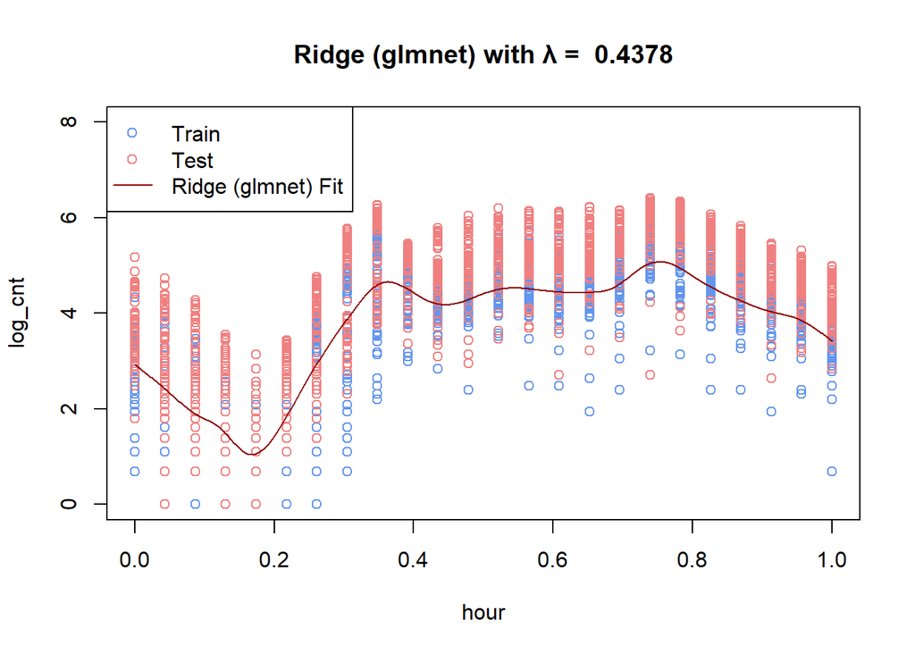

```r
#=== 6. Plot the fit
plot (log_cnt ~ hour, data=bike_data_train, col = "cornflowerblue", ylim = c(0,8), main = paste ("Ridge (glmnet) with λ = ", round(opt_lambda,4)))
lines (bike_data_test$hour, bike_data_test$log_cnt, type = "p", col ="lightcoral")

hours_grid <- seq(0,1, length.out = 1000)
x_cv_grid <- ns (hours_grid, knots = knots, intercept = TRUE)
y_hat_cv_grid <- predict (cv_fit, newx = x_cv_grid, s = "lambda.1se")
lines (hours_grid, y_hat_cv_grid, lty = 1, col="darkred") #Ridge (glmnet) fitted curve

legend (x="topleft", pch = c(1,1,NA), lty = c(NA, NA, 1), col= c("cornflowerblue", "lightcoral","darkred"), legend = c("Train", "Test", "Ridge (glmnet) Fit"))
```

#### 💪 Problem 2.3

Repeat Problem 2.2, however, use the optimal $\lambda$ that minimises the mean cross-validated error. Compare the RMSE for the training and test data to those in Problem 2.2.

**Tip**

The `help()` function will be very useful here.

```r
#=== 1. Prepare data
knots <- seq (0.05, 0.95, length.out = 25)
x_train <- ns (bike_data_train$hour, knots = knots, intercept = TRUE)
x_test <- ns (bike_data_test$hour, knots = knots, intercept = TRUE)

#=== 2. Fit Ridge regression with Cross-validation
set.seed (0)
cv_fit <- cv.glmnet(x = x_train, y = y_train, alpha = 0, nfolds = 10)

#=== 3. Choosing the optimal Lambda using min rule
min_lambda <- cv_fit$lambda.min
cat ("Best lambda (min):", min_lambda, "\n")
```

```
Best lambda (min): 0.07475111
```

```r
#=== 4. Predict fitted values with lambda.min
yhat_train_cv_min <- predict (cv_fit, newx = x_train, s = "lambda.min")
yhat_test_cv_min <- predict (cv_fit, newx = x_test, s = "lambda.min")

#=== 5. Compute RMSE
RMSE_train_cv_min <- sqrt (mean((y_train - yhat_train_cv_min)^2))
RMSE_test_cv_min <- sqrt (mean((y_test - yhat_test_cv_min)^2))
cat("RMSE (Train):", RMSE_train_cv_min, "\n")
```

```
RMSE (Train): 0.6919639
```

```r
cat("RMSE (Test):", RMSE_test_cv_min, "\n")
```

```
RMSE (Test): 1.002668
```

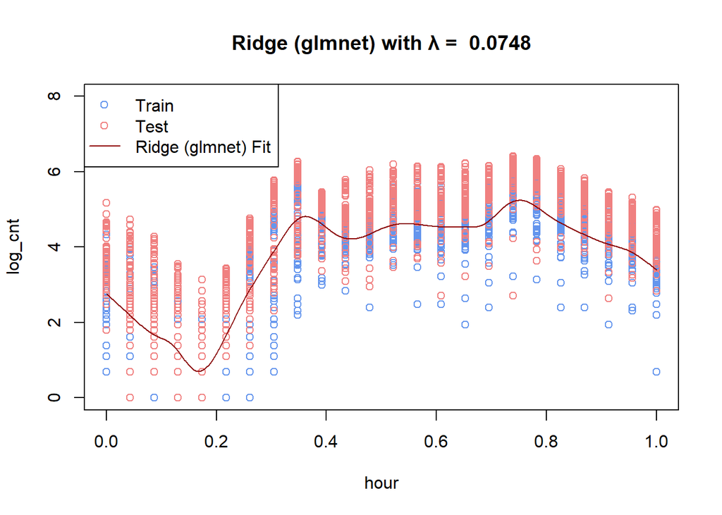

```r
#=== 6. Plot the fit
plot (log_cnt ~ hour, data=bike_data_train, col = "cornflowerblue", ylim = c(0,8), main = paste ("Ridge (glmnet) with λ = ", round(min_lambda,4)))
lines (bike_data_test$hour, bike_data_test$log_cnt, type = "p", col ="lightcoral")

hours_grid <- seq(0,1, length.out = 1000)
x_cv_grid <- ns (hours_grid, knots = knots, intercept = TRUE)
y_hat_cv_grid <- predict (cv_fit, newx = x_cv_grid, s = "lambda.min")
lines (hours_grid, y_hat_cv_grid, lty = 1, col="darkred") #Ridge (glmnet) fitted curve

legend (x="topleft", pch = c(1,1,NA), lty = c(NA, NA, 1), col= c("cornflowerblue", "lightcoral","darkred"), legend = c("Train", "Test", "Ridge (glmnet) Fit"))
```

```r
#=== 7.Compare results

RMSE_compare <- data.frame (Model = c("Lambda.1se rule", "Lambda.min rule"), RMSE_Train = c(RMSE_train_cv, RMSE_train_cv_min), RMSE_Test = c(RMSE_test_cv, RMSE_test_cv_min))
print (RMSE_compare)
```

```
            Model RMSE_Train RMSE_Test
1 Lambda.1se rule  0.7111962  1.000773
2 Lambda.min rule  0.6919639  1.002668
```

```r
#Conclusion: While both lambda choices yield similar test performance, the Lambda.1se rule leads to a simpler model with slightly better generalization. In contrast, Lambda.min fits the training data better but may overfit slightly, as seen from the marginally higher test RMSE.
```

#### 💪 Problem 2.4

Repeat Problem 2.2 using L1 regularisation. Compare the RMSE for the training and test data to those in Problem 2.2.

**Tip**

The `help()` function will be very useful here to set the argument `alpha` (to the `cv.glmnet()` function).

```r
#=== 1. Prepare data
knots <- seq (0.05, 0.95, length.out = 25)
x_train <- ns (bike_data_train$hour, knots = knots, intercept = TRUE)
x_test <- ns (bike_data_test$hour, knots = knots, intercept = TRUE)

#=== 2. Fit Ridge regression with cross-validation (L1 regularisation)
set.seed (0)
cv_model <- cv.glmnet(x = x_train, y = y_train, alpha = 1, nfolds = 10) #set alpha = 1 (LASSO)

#=== 3. Choosing the optimal Lambda using 1-SE rule
opt_lambda_lasso <- cv_model$lambda.1se
cat ("Optimal lambda (1 - SE rule):", opt_lambda_lasso, "\n")
```

```
Optimal lambda (1 - SE rule): 0.04179192
```

```r
#=== 4. Predict fitted values with lambda.1se
yhat_train_lasso <- predict (cv_model, newx = x_train, s = "lambda.1se")
yhat_test_lasso <- predict (cv_model, newx = x_test, s = "lambda.1se")

#=== 5. Compute RMSE
RMSE_train_lasso <- sqrt (mean((y_train - yhat_train_lasso)^2))
RMSE_test_lasso <- sqrt (mean((y_test - yhat_test_lasso)^2))
cat("RMSE (Train):", RMSE_train_lasso, "\n")
```

```
RMSE (Train): 0.7085636
```

```r
cat("RMSE (Test):", RMSE_test_lasso, "\n")
```

```
RMSE (Test): 1.003751
```

[figure not shown]

```r
#=== 6. Plot the fit
plot (log_cnt ~ hour, data=bike_data_train, col = "cornflowerblue", ylim = c(0,8), main = paste ("Ridge (glmnet) with λ = ", round(opt_lambda_lasso,3)))
lines (bike_data_test$hour, bike_data_test$log_cnt, type = "p", col ="lightcoral")

hours_grid <- seq(0,1, length.out = 1000)
x_lasso_grid <- ns (hours_grid, knots = knots, intercept = TRUE)
y_hat_lasso_grid <- predict (cv_model, newx = x_lasso_grid, s = "lambda.1se")
lines (hours_grid, y_hat_lasso_grid, lty = 1, col="darkred") #Ridge (glmnet) fitted curve

legend (x="topleft", pch = c(1,1,NA), lty = c(NA, NA, 1), col= c("cornflowerblue", "lightcoral","darkred"), legend = c("Train", "Test", "Ridge (glmnet) Fit"))
```

```r
#=== 7.Compare results

RMSE_comp <- data.frame (Model = c("L2 regularisation", "L1 regularisation"), RMSE_Train = c(RMSE_train_cv, RMSE_train_lasso), RMSE_Test = c(RMSE_test_cv, RMSE_test_lasso))
print (RMSE_comp)
```

```
              Model RMSE_Train RMSE_Test
1 L2 regularisation  0.7111962  1.000773
2 L1 regularisation  0.7085636  1.003751
```

## 3. Regularised regression for bike rental data with more features and data (3 marks)

We now consider the full dataset and use many more features. We use the first one and a half years (Jan 1, 2011 - May 31, 2012) of data for training and the last half year (June 1, 2012- Dec 31, 2012) for testing.

We will use the following categorical features:

- `weathersit`: Clear (1), cloudy (2), light rain (3), heavy rain (4).
- `weekday`: Sun (0), Mon (1), Tue (2), Wed (3), Thu (4), Fri (5), Sat (6).
- `season`: Winter (1), spring (2), summer (3), fall (4).

We will use the common approach in statistics that creates $K-1$ dummy variables for a categorical variable with $K$ levels. The first level is the reference category. The following code constructs these so called one-hot encodings and adds them to the dataset `bike_data`.

```r
# One hot for weathersit
one_hot_encode_weathersit <- model.matrix(~ as.factor(weathersit) - 1,data = bike_data)
one_hot_encode_weathersit  <- one_hot_encode_weathersit[, -1] # Remove reference category
colnames(one_hot_encode_weathersit) <- c('cloudy', 'light rain', 'heavy rain')
bike_data <- cbind(bike_data, one_hot_encode_weathersit)

# One hot for weekday
one_hot_encode_weekday <- model.matrix(~ as.factor(weekday) - 1,data = bike_data)
one_hot_encode_weekday  <- one_hot_encode_weekday[, -1] # Remove reference category
colnames(one_hot_encode_weekday) <- c('Mon', 'Tue', 'Wed', 'Thu', 'Fri', 'Sat')
bike_data <- cbind(bike_data, one_hot_encode_weekday)

# One hot for season
one_hot_encode_season <- model.matrix(~ as.factor(season) - 1,data = bike_data)
one_hot_encode_season  <- one_hot_encode_season[, -1] # Remove reference category
colnames(one_hot_encode_season) <- c('Spring', 'Summer', 'Fall')
bike_data <- cbind(bike_data, one_hot_encode_season)
```

#### 💪 Problem 3.1

Fit a spline regression to the training data with an L1 regularisation. Find the optimal $\lambda$ by applying the one-standard deviation rule when cross-validating the training data using 10 folds. Compute the RMSE (using the optimal $\lambda$) for the training and test data. For the spline, use the `splines` package in R to create natural cubic splines basis functions of the variable `hour` with 10 degrees of freedom, i.e. use the `ns()` function with df=10 as input argument. Moreover, set `intercept=FALSE` and add it manually to your design matrix instead.

The following variables should be included in the regression:

- Response variable: `log_cnt`.
- Features: `hour` (via the cubic spline described above), `yr`, `holiday`, `workingday`, `temp`, `atemp`, `hum`, `windspeed`, and all the dummy variables created above.

**Tip**

First create the design matrix of interest (you have to exclude the original variables you did the one-hot coding for). When creating the spline basis for the test data, you will need to use the same knots as when constructing the basis functions for the training dataset. If the spline is stored in a variable `spline_basis`, you can extract the knots by using `knots<-attr(spline_basis, "knots")` and then use the `knots` argument when constructing the design matrix for the test data, e.g. `ns(bike_all_data_test$hour, df=10, knots=knots, intercept = FALSE)`.

```r
#=== 1. Prepare data
bike_alldata_train <- bike_data[bike_data$dteday >= as.Date("2011-01-01") & bike_data$dteday <= as.Date("2012-05-31"), ]
bike_alldata_test <- bike_data[bike_data$dteday >= as.Date("2012-06-01") & bike_data$dteday <= as.Date("2012-12-31"), ]

y_alltrain <- bike_alldata_train$log_cnt
y_alltest <- bike_alldata_test$log_cnt

#=== 2. Create spline basis for variable hour
spline_train <- ns(bike_alldata_train$hour, df=10, intercept = FALSE)

#=== 3. Extract knots and apply to test set
knots <- attr(spline_train, "knots")
spline_test <- ns (bike_alldata_test$hour, df = 10,knots = knots, intercept = FALSE)

#=== 4. Design matrix for training and test data

x_alltrain <- as.matrix(
  cbind(1, spline_train,
  bike_alldata_train[, c('yr','holiday', 'workingday', 'temp', 'atemp', 'hum'
                         ,'windspeed') ],
  bike_alldata_train [, c('cloudy', 'light rain', 'heavy rain', #weather dummies
                          'Mon', 'Tue', 'Wed', 'Thu', 'Fri','Sat', #weekday
                          'Spring', 'Summer', 'Fall')])) #season dummies

x_alltest <- as.matrix(
  cbind(1, spline_test,
  bike_alldata_test[, c('yr','holiday', 'workingday', 'temp', 'atemp', 'hum'
                          ,'windspeed') ],
  bike_alldata_test [, c('cloudy', 'light rain', 'heavy rain',
                          'Mon', 'Tue', 'Wed', 'Thu', 'Fri', 'Sat',
                          'Spring', 'Summer', 'Fall')]))

colnames (x_alltrain) [2:11] <- paste0("Polynomial_", 1:10)
#=== 5. Fit Lasso with cross-validation
set.seed(0)
cv_lasso <- cv.glmnet(x_alltrain, y_alltrain, alpha = 1, nfolds = 10, intercept = FALSE)

#=== 6. Choosing the best lambda
best_lambda_lasso <- cv_lasso$lambda.1se
cat ("Optimal lambda (L1, 1-SE):", best_lambda_lasso, "\n")
```

```
Optimal lambda (L1, 1-SE): 0.01797346
```

```r
#=== 7. Compute the RMSE
y_alltrain_hat <- predict(cv_lasso, newx = x_alltrain, s = "lambda.1se")
y_alltest_hat <- predict (cv_lasso, newx = x_alltest, s = "lambda.1se")

RMSE_train_lasso <- sqrt(mean((y_alltrain - y_alltrain_hat)^2))
RMSE_test_lasso <- sqrt(mean((y_alltest - y_alltest_hat)^2))
cat("RMSE (Train):", RMSE_train_lasso, "\n")
```

```
RMSE (Train): 0.7284706
```

```r
cat ("RMSE (Test):", RMSE_test_lasso, "\n")
```

```
RMSE (Test): 0.7114325
```

#### 💪 Problem 3.2

Which three features in Problem 3.1 seem to be the most important?

**Tip**

To explore which variables are most important, you can re-estimate the model in Problem 3.1 without cross-validation (using `glmnet()`). Note that you can apply the `plot()` function to an object returned by `glmnet()` using the arguments `xvar="lambda"` or `xvar="norm"`, and `label="TRUE"`, which allows you to visualise the lasso path.

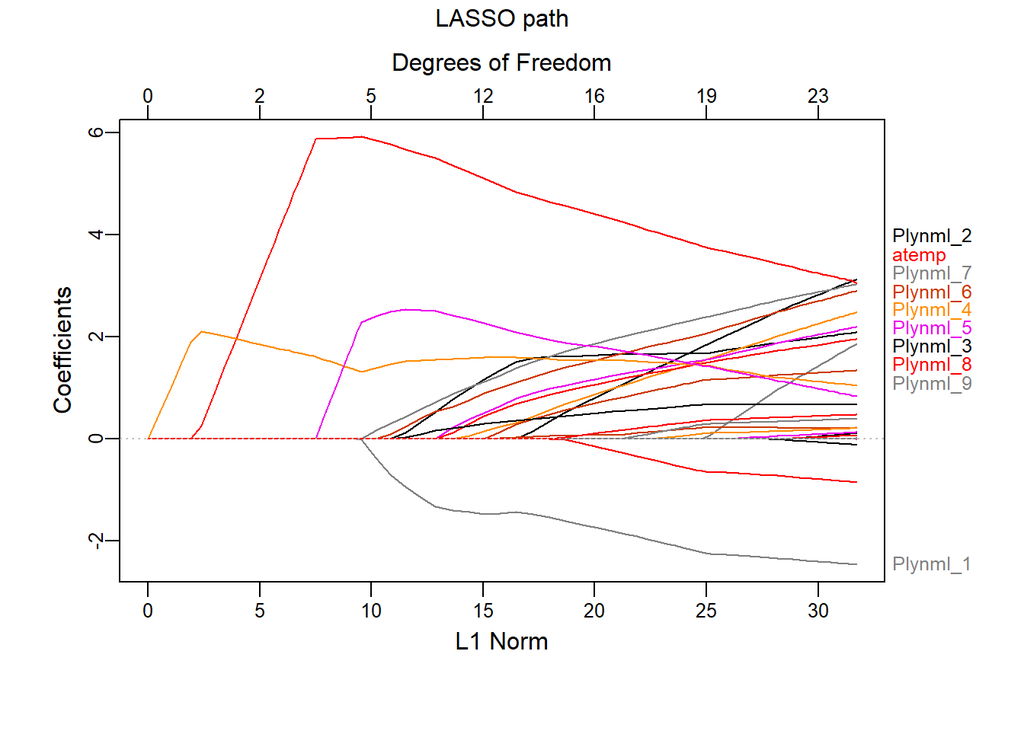

```r
#=== 1. Re-estimate the model without cross-validation
set.seed (0)
lasso_model <- glmnet(x = x_alltrain, y = y_alltrain, alpha = 1, intercept = FALSE)
#=== 2. Plot LASSO coefficient paths
#plot (lasso_model, xvar = "norm", label = "TRUE")
#title ("LASSO path - Most Important Features", line = 3 )

suppressMessages(library(plotmo))

plot_glmnet (lasso_model, xvar = "norm", type = "1", main = "LASSO path")
```

```r
colnames (x_alltrain) [1]  <- "Constant"

#print(colnames (x_alltrain))
#Conclusion:
```

#### 💪 Problem 3.3

Carry out a residual analysis in Problem 3.1 for the training data. What can you say about the assumption of independent residuals? Repeat the same for the test data.

**Tip**

Plot the autocorrelation function of the residuals to validate the independence assumption.

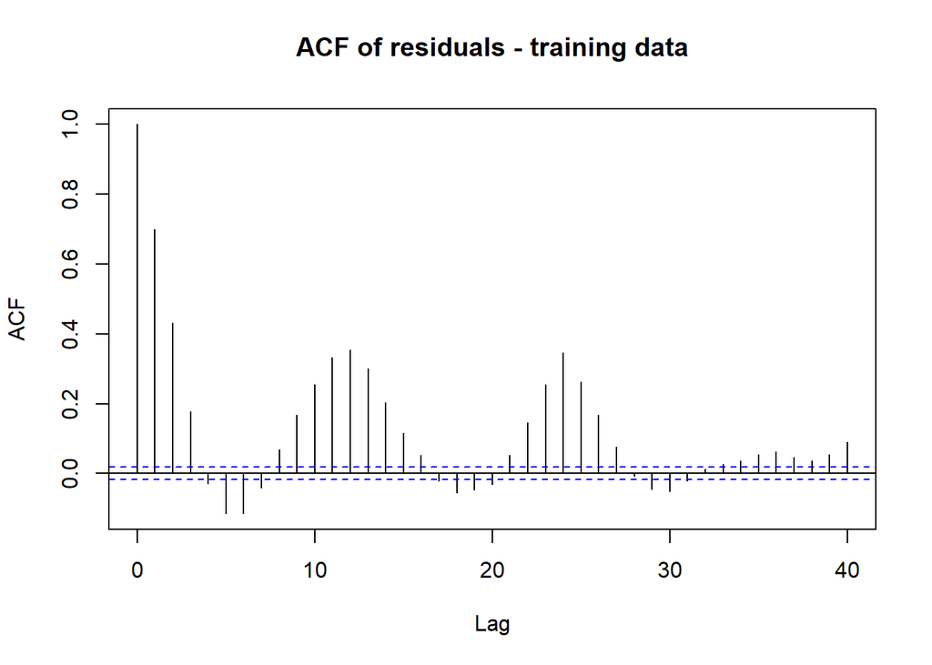

```r
#=== 1. Compute the residuals
residuals_train <- y_alltrain - y_alltrain_hat
residuals_test <- y_alltest - y_alltest_hat

#=== 2. Plot of autocorrelation function
acf(residuals_train, main = "ACF of residuals - training data")
```

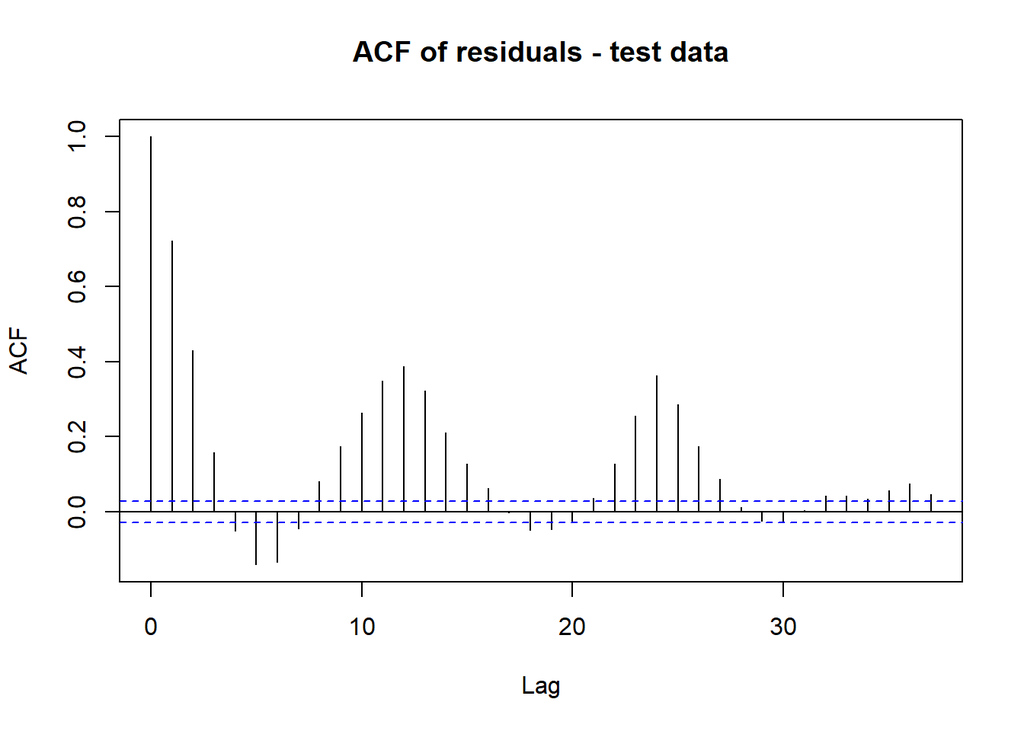

```r
acf(residuals_test, main = "ACF of residuals - test data")
```